# Исследование временных рядов макроэкономических показателей российской экономики

Б. Романов, Д.Пак, М. Вотякова

# Задание

**1. Загрузите экономические показатели из базы Sophist**

Используя пакет `sophisthse`, загрузите данные по следующим показателям: - Индекс производства С. Добыча полезных ископаемых (IP_CEA_M) - Индекс производства D. Обрабатывающие производства (IP_DEA_M) - Индекс реального оборота розничной торговли (RTRD_M_DIRI)

```r
library(forecast)
library(sophisthse)
library(tidyverse)
library(stringr)
library(gridExtra)
```

```r
cea <- sophisthse("IP_CEA_M")
dea <- sophisthse("IP_DEA_M")
rtrd <- sophisthse("RTRD_M_DIRI")
```

**2. Приведите показатели к одному базису**

```r
rtrd <- rtrd[ , "RTRD_M_DIRI"]
head(rtrd)
```

```
##        Jan   Feb   Mar   Apr   May   Jun
## 1994 100.0 100.0 117.7 107.6 102.0 106.6
```

```r
cea <- cea[, "IP_CEA_M"]
head(cea)
```

```
##         Jan    Feb    Mar    Apr    May    Jun
## 2002 100.00  91.90 101.64  98.59 103.52 105.80
```

```r
dea <- dea[, "IP_DEA_M"]
head(dea)
```

```
##         Jan    Feb    Mar    Apr    May    Jun
## 2002 100.00 101.50 112.67 111.76 106.85 111.12
```

```r
rtrd_c <- window(rtrd, start = c(2002, 1))
head(rtrd_c)
```

```
##        Jan   Feb   Mar   Apr   May   Jun
## 2002 114.8 112.6 120.8 121.2 118.5 120.6
```

```r
# rtrd_1 <- rtrd_c/1.148
rtrd_1 <- rtrd_c/as.numeric((window(rtrd_c, 2002, c(2002, 1))/100))
head(rtrd_1)
```

```
##            Jan       Feb       Mar       Apr       May       Jun
## 2002 100.00000  98.08362 105.22648 105.57491 103.22300 105.05226
```

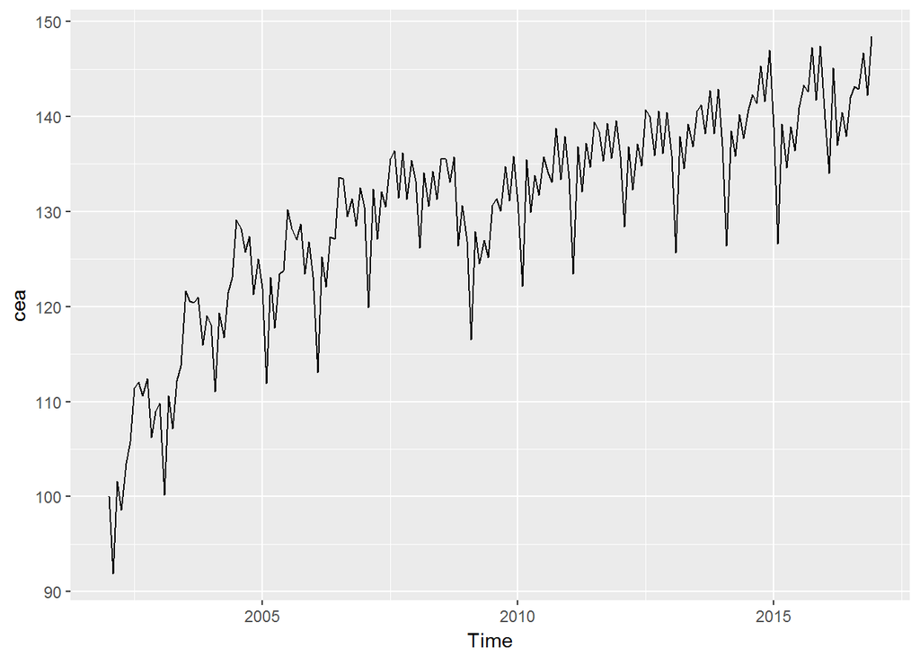

```r
autoplot(cea)
```

**3. Визуализация показателей**

Постройте график, отображающий динамику показателей

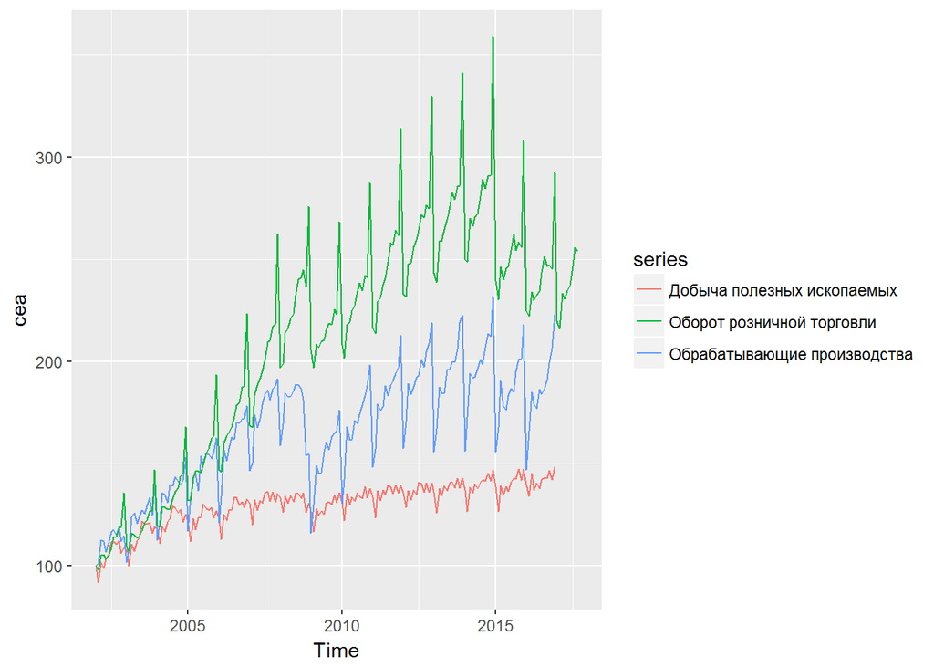

```r
autoplot(cea, series = "Добыча полезных ископаемых") +
  autolayer(dea, series = "Обрабатывающие производства") +
  autolayer(rtrd_1, series = "Оборот розничной торговли")
```

Присутствуют ежегодные сезонные колебания.

**4. Сезонная декомпозиция**

Выполните сезонную декомпозицию рядов, используя метод STL с изменяющимися сезонными коэффициентами. Ширину окна сглаживания подберите таким образом, чтобы в остатках ряда не было заметно сезонных колебаний.

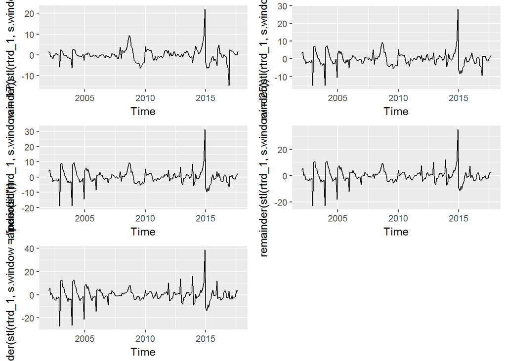

```r
p1 <-  autoplot(remainder(stl(rtrd_1, s.window = 7)))
p2 <-  autoplot(remainder(stl(rtrd_1, s.window = 13)))
p3 <-  autoplot(remainder(stl(rtrd_1, s.window = 17)))
p4 <-  autoplot(remainder(stl(rtrd_1, s.window = 25)))
p5 <-  autoplot(remainder(stl(rtrd_1, s.window = 'periodic')))

grid.arrange(p1, p2, p3, p4, p5, ncol = 2)
```

Для данного ряда подходит значение 7.

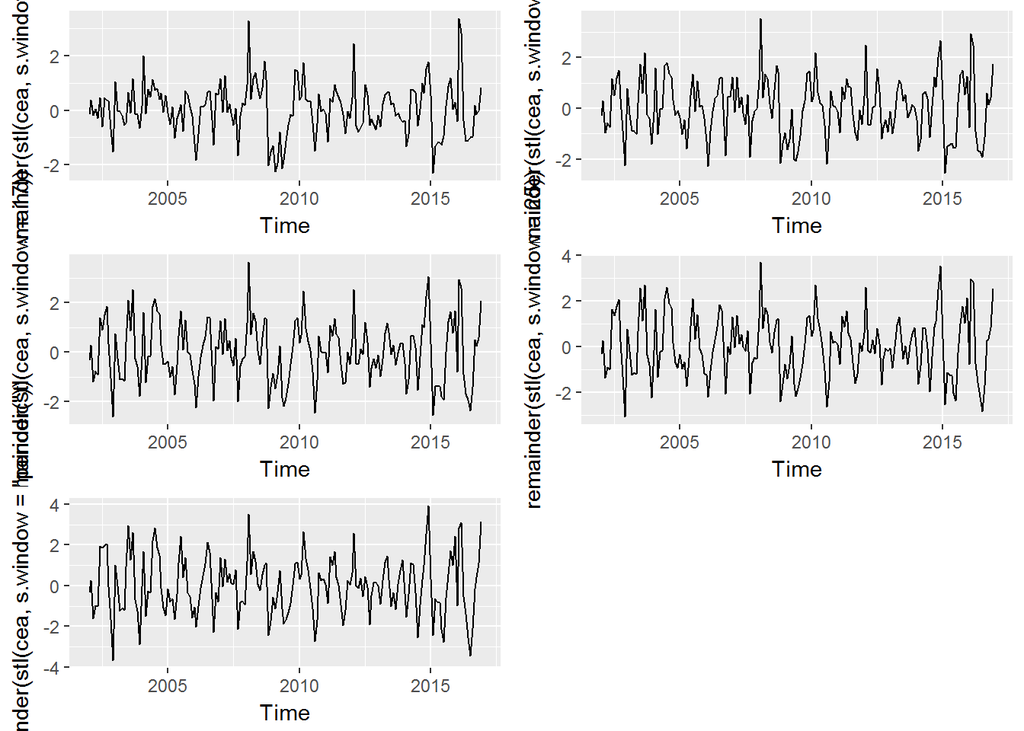

```r
c1 <-  autoplot(remainder(stl(cea, s.window = 7)))
c2 <-  autoplot(remainder(stl(cea, s.window = 13)))
c3 <-  autoplot(remainder(stl(cea, s.window = 17)))
c4 <-  autoplot(remainder(stl(cea, s.window = 25)))
c5 <-  autoplot(remainder(stl(cea, s.window = 'periodic')))

grid.arrange(c1, c2, c3, c4, c5, ncol = 2)
```

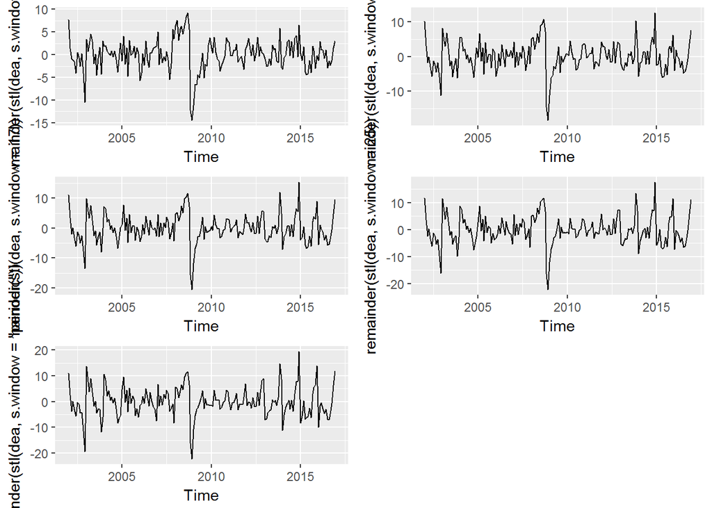

```r
d1 <-  autoplot(remainder(stl(dea, s.window = 7)))
d2 <-  autoplot(remainder(stl(dea, s.window = 13)))
d3 <-  autoplot(remainder(stl(dea, s.window = 17)))
d4 <-  autoplot(remainder(stl(dea, s.window = 25)))
d5 <-  autoplot(remainder(stl(dea, s.window = 'periodic')))

grid.arrange(d1, d2, d3, d4, d5, ncol = 2)
```

Для данного ряда подходит значение 13.

```r
rtrd_stl <- stl(rtrd_1, s.window = 7)


cea_stl <- stl(cea, s.window = 9)

dea_stl <-stl(dea, s.window = 13)
```

**5. Сравнение динамики показателей**

Постройте график, на котором сравнивается динамика сезонно-скорректированных показателей.

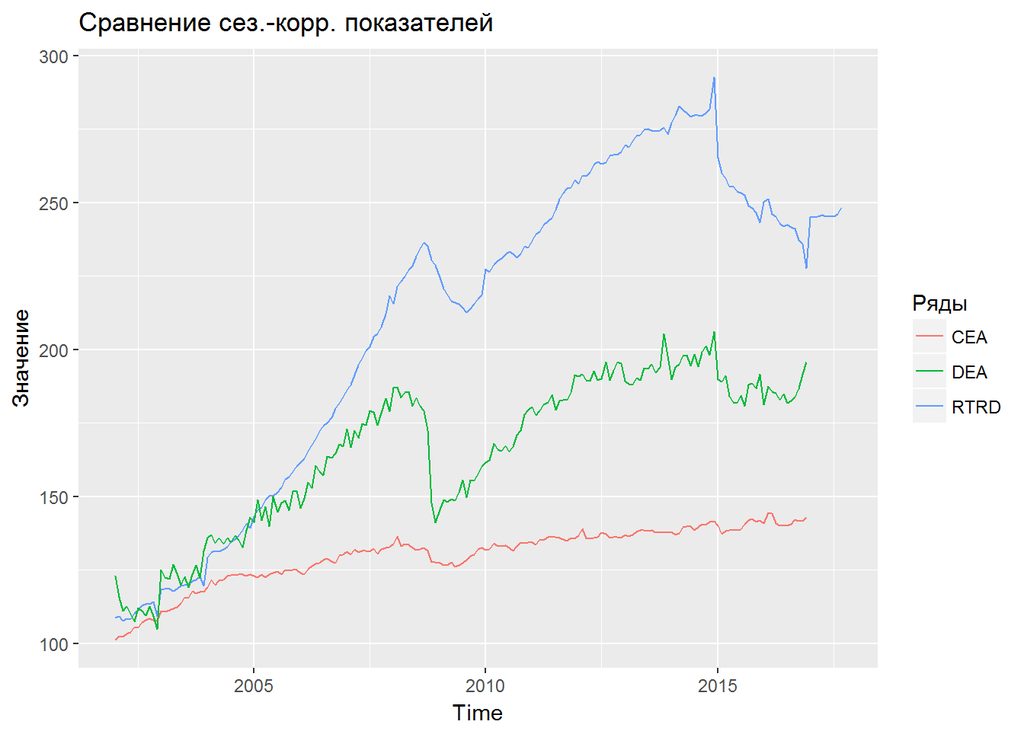

```r
autoplot(seasadj(rtrd_stl), series = 'RTRD') +
  autolayer(seasadj(cea_stl), series = 'CEA') +
  autolayer(seasadj(dea_stl), series = "DEA") +
  labs (title = "Сравнение сез.-корр. показателей", y = "Значение", color = "Ряды")
```

Постройте график, на котором сравниваются тренды показателей

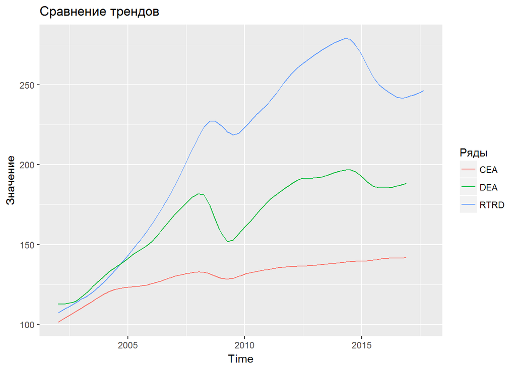

```r
autoplot(trendcycle(rtrd_stl), series = 'RTRD') +
  autolayer(trendcycle(cea_stl), series = 'CEA') +
  autolayer(trendcycle(dea_stl), series = "DEA") +
  labs (title = "Сравнение трендов", y = "Значение", color = "Ряды")
```

Постройте график, на котором сравниваются нерегулярные компоненты показателей

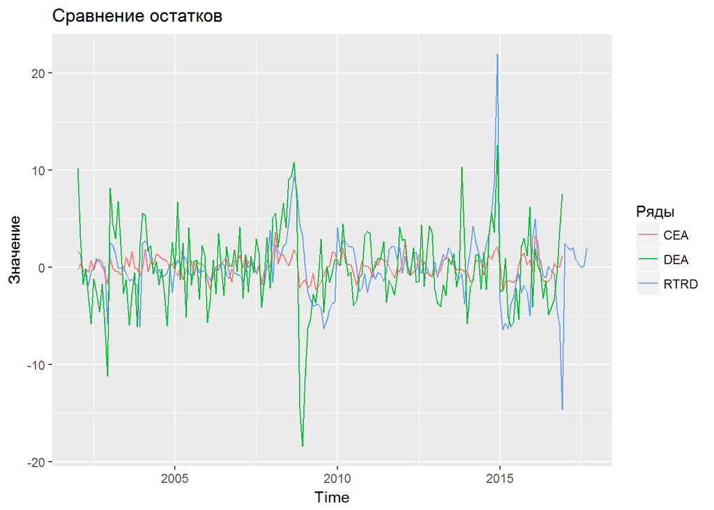

```r
autoplot(remainder(rtrd_stl), series = 'RTRD') +
  autolayer(remainder(cea_stl), series = 'CEA') +
  autolayer(remainder(dea_stl), series = "DEA") +
  labs (title = "Сравнение остатков", y = "Значение", color = "Ряды")
```

**Ответьте на вопросы:**

Какой из графиков нагляднее показывает отличие в реакции показателей на экономические кризисы 2008 и 2014 года?

**Сезонно-скорректированные ряды**

Какая из отраслей быстрее всего реагирует на кризис?

** Розничная торговля**

Для какой из отраслей этот эффект наиболее выраженный?

**Обрабатывающая промышленность**

Какая из отраслей быстрее всего восстанавливалась после кризиса 2008 года?

**Добыча полезных ископаемых**

Отличается ли поведение показателей в кризисах 2008 и 2014 года?

**В 2014 году кризис практически не затронул добычу полезных ископаемых(видно по тренду), два других показателя повели себя аналогичным образом**

**6. Преобразования данных**

Подберите наилучшее значение параметра $\lambda$ преобразования Бокса-Кокса для каждого показателя. При необходимости, скорректируйте значение параметра для обеспечения простой интерпретации преобразованных данных.

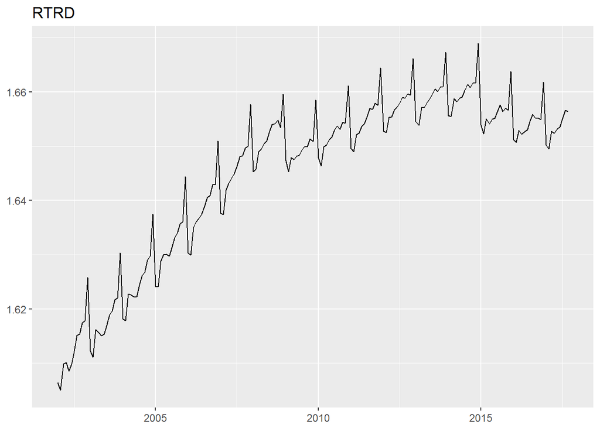

```r
best_rtrd <- BoxCox.lambda(rtrd_1)
best_cea <- BoxCox.lambda(cea)
best_dea <- BoxCox.lambda(dea)
autoplot(BoxCox(rtrd_1, best_rtrd)) +
    labs(title = "RTRD",
         x = NULL, y = NULL)
```

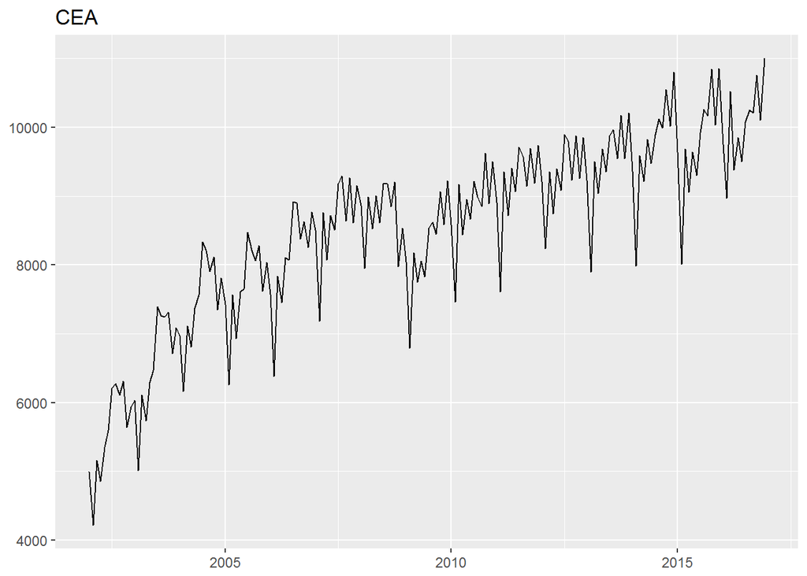

```r
 autoplot(BoxCox(cea, best_cea))  +
    labs(title = "CEA",
         x = NULL, y = NULL)
```

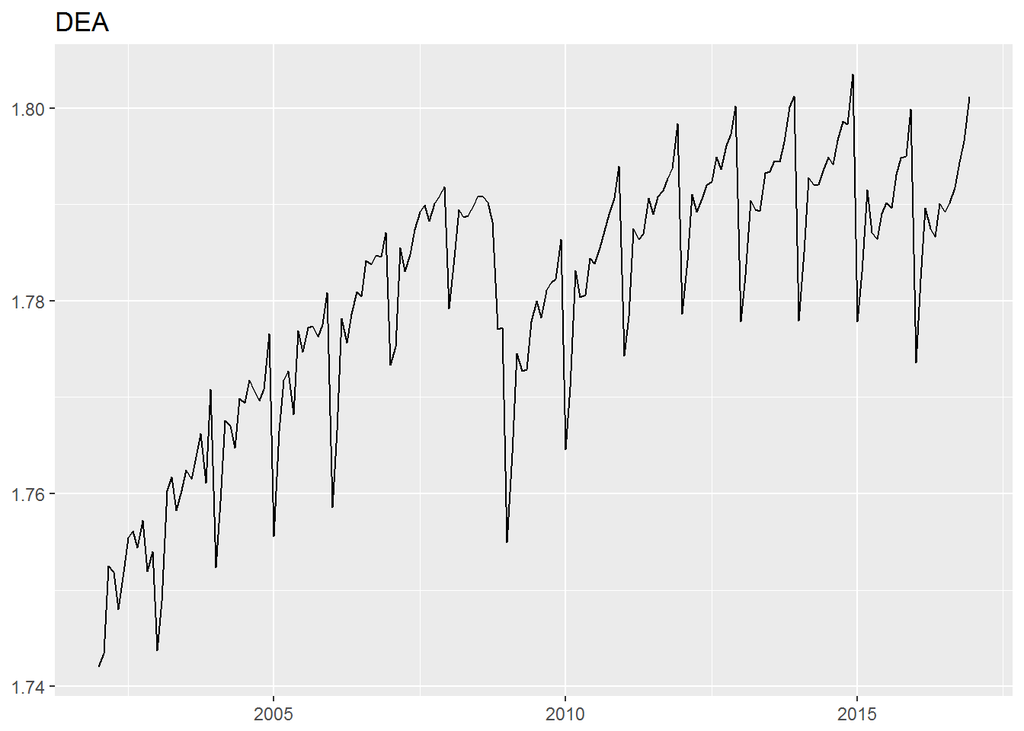

```r
  autoplot(BoxCox(dea, best_dea)) +
    labs(title = "DEA",
         x = NULL, y = NULL)
```

```r
  rtrdbox <- BoxCox(rtrd_1, best_rtrd)
  ceabox <- BoxCox(cea, best_cea)
  deabox <- BoxCox(dea, best_dea)
```

Повторите сезонную декомпозицию методом STL, на этот раз используя фиксированный набор сезонных коэффициентов (`s.window = 'periodic'`) и преобразованные данные.

```r
rtrd_stl_bc <- stl(rtrdbox, s.window = 'periodic')

cea_stl_bc <- stl(ceabox, s.window = 'periodic')

dea_stl_bc <-stl(deabox, s.window = 'periodic')
```

Получите модель каждого ряда (сумма тренда и сезонного компонента). Затем постройте три графика, на каждом из которых в сравнивается исходный (непреобразованный) показатель и модель. Для перевода данных модели в шкалу исходного показателя используйте функцию `InvBoxCox()`.

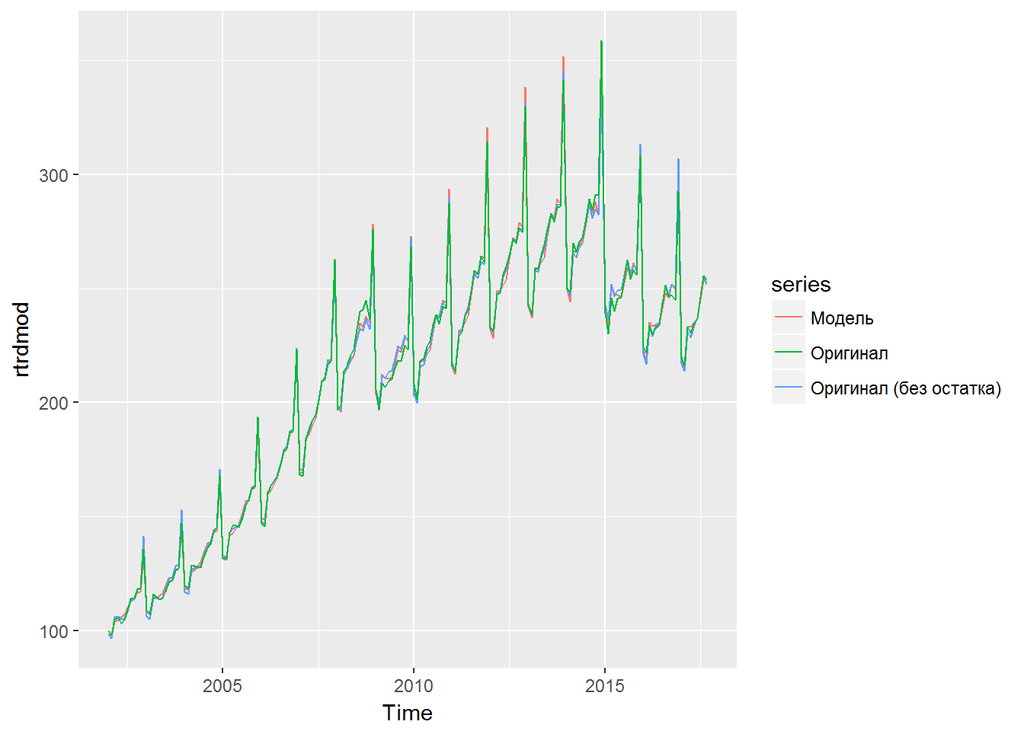

```r
rtrdmod <- InvBoxCox((seasonal(rtrd_stl_bc) + trendcycle(rtrd_stl_bc)), best_rtrd)

ceamod <- InvBoxCox((seasonal(cea_stl_bc) + trendcycle(cea_stl_bc)), best_cea)
deamod  <- InvBoxCox((seasonal(dea_stl_bc) + trendcycle(dea_stl_bc)), best_dea)

rtor <- seasonal(rtrd_stl) + trendcycle(rtrd_stl)
ceaor <- seasonal(cea_stl) + trendcycle(cea_stl)
deaor  <- seasonal(dea_stl) + trendcycle(dea_stl)

autoplot(rtrdmod, series = "Модель") +
  autolayer(rtor, series = "Оригинал (без остатка)") +
  autolayer(rtrd_1, series = "Оригинал")
```

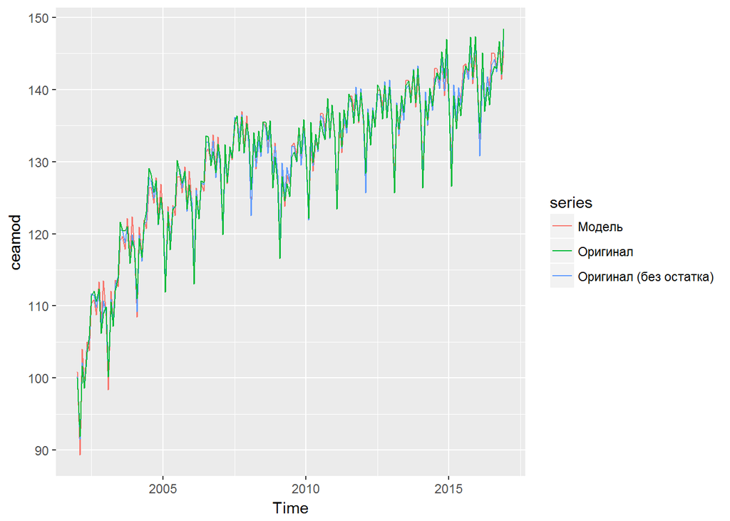

```r
autoplot(ceamod, series = "Модель") +
  autolayer(ceaor, series = "Оригинал (без остатка)") +
   autolayer(cea, series = "Оригинал")
```

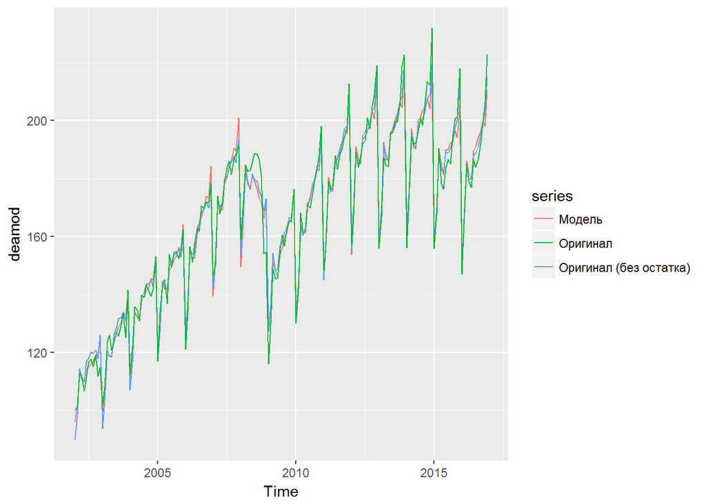

```r
autoplot(deamod, series = "Модель") +
  autolayer(deaor, series = "Оригинал (без остатка)")+
   autolayer(dea, series = "Оригинал")
```